# IODS course project

```r
summary(test)
```

```
##        zn              indus               chas               nox
##  Min.   :-0.4872   Min.   :-1.55630   Min.   :-0.27233   Min.   :-1.4644
##  1st Qu.:-0.4872   1st Qu.:-0.91166   1st Qu.:-0.27233   1st Qu.:-0.9208
##  Median :-0.4872   Median :-0.29325   Median :-0.27233   Median :-0.1959
##  Mean   : 0.1654   Mean   : 0.01543   Mean   : 0.03646   Mean   :-0.0423
##  3rd Qu.: 0.4025   3rd Qu.: 1.01499   3rd Qu.:-0.27233   3rd Qu.: 0.6218
##  Max.   : 3.5861   Max.   : 2.42017   Max.   : 3.66477   Max.   : 2.7296
##        rm                age                dis                rad
##  Min.   :-3.87641   Min.   :-2.33313   Min.   :-1.24278   Min.   :-0.98187
##  1st Qu.:-0.61432   1st Qu.:-0.92010   1st Qu.:-0.72962   1st Qu.:-0.72347
##  Median :-0.05499   Median : 0.15010   Median :-0.24654   Median :-0.52248
##  Mean   :-0.05193   Mean   :-0.06702   Mean   : 0.07247   Mean   : 0.06976
##  3rd Qu.: 0.48763   3rd Qu.: 0.84640   3rd Qu.: 0.79499   3rd Qu.: 1.65960
##  Max.   : 3.55153   Max.   : 1.11639   Max.   : 3.28405   Max.   : 1.65960
##       tax              ptratio             black             lstat
##  Min.   :-1.30676   Min.   :-2.70470   Min.   :-3.1516   Min.   :-1.52961
##  1st Qu.:-0.81577   1st Qu.:-0.39518   1st Qu.: 0.1984   1st Qu.:-0.82874
##  Median :-0.42861   Median : 0.29768   Median : 0.3828   Median :-0.27910
##  Mean   : 0.06049   Mean   : 0.05858   Mean   : 0.1899   Mean   :-0.04539
##  3rd Qu.: 1.52941   3rd Qu.: 0.80578   3rd Qu.: 0.4326   3rd Qu.: 0.55446
##  Max.   : 1.79642   Max.   : 1.17530   Max.   : 0.4406   Max.   : 2.99212
##       medv
##  Min.   :-1.76499
##  1st Qu.:-0.45751
##  Median :-0.06881
##  Mean   : 0.02223
##  3rd Qu.: 0.47484
##  Max.   : 2.98650
```

```r
nrow(train)
```

```
## [1] 404
```

```r
nrow(test)
```

```
## [1] 102
```

4.Fit the linear discriminant analysis on the train set. Use the categorical crime rate as the target variable and all the other variables in the dataset as predictor variables.

```r
# linear discriminant analysis
lda.fit <- lda(crime ~., data = train)

# print the lda.fit object
lda.fit
```

```
## Call:
## lda(crime ~ ., data = train)
##
## Prior probabilities of groups:
##         low  medium_low medium_high        high
##   0.2351485   0.2549505   0.2673267   0.2425743
##
## Group means:
##                     zn      indus        chas        nox         rm        age
## low          0.8570709 -0.8891885 -0.06511327 -0.8555511  0.4311959 -0.8613663
## medium_low  -0.0980157 -0.3330353 -0.04298342 -0.5810941 -0.1265220 -0.3638475
## medium_high -0.3744892  0.1641854  0.12867188  0.4144643  0.1201788  0.4247625
## high        -0.4872402  1.0149946 -0.07145661  1.0273751 -0.3634105  0.8190637
##                    dis        rad        tax     ptratio      black
## low          0.8546033 -0.6844787 -0.7347143 -0.43407287  0.3799738
## medium_low   0.3635542 -0.5436697 -0.4855274 -0.06690884  0.3129595
## medium_high -0.3807817 -0.4512369 -0.3356010 -0.34085893  0.1068622
## high        -0.8663376  1.6596029  1.5294129  0.80577843 -1.0126936
##                    lstat         medv
## low         -0.765699236  0.531498422
## medium_low  -0.150565733  0.001711122
## medium_high  0.002618101  0.198287976
## high         0.944865817 -0.758684931
##
## Coefficients of linear discriminants:
##                  LD1          LD2         LD3
## zn       0.109856781  0.575394950 -1.04858722
## indus    0.014326134 -0.233983031  0.23429977
## chas    -0.011830941  0.051975021  0.07925610
## nox      0.284902527 -0.982260875 -1.27181274
## rm       0.026534201 -0.062377095 -0.14266081
## age      0.235151197 -0.367453360 -0.05516810
## dis     -0.101644964 -0.270884237  0.12992821
## rad      4.024811753  0.862887335 -0.12437580
## tax      0.136886133  0.053810272  0.42804739
## ptratio  0.154051880 -0.010887761 -0.31149583
## black   -0.130427597 -0.006811925  0.08941767
## lstat    0.092724554 -0.146070487  0.47145038
## medv     0.002954548 -0.439214986 -0.16619236
##
## Proportion of trace:
##    LD1    LD2    LD3
## 0.9644 0.0273 0.0083
```

5. Save the crime categories from the test set and then remove the categorical crime variable from the test dataset. Then predict the classes with the LDA model on the test data.

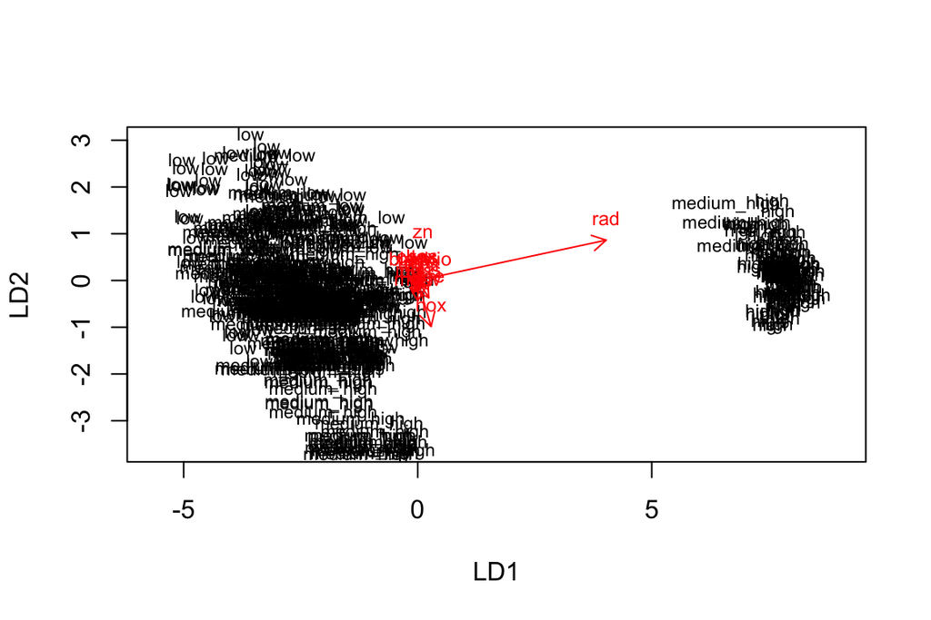

```r
# the function for lda biplot arrows
lda.arrows <- function(x, myscale = 1, arrow_heads = 0.1, color = "red", tex = 0.75, choices = c(1,2)){
  heads <- coef(x)
  arrows(x0 = 0, y0 = 0,
         x1 = myscale * heads[,choices[1]],
         y1 = myscale * heads[,choices[2]], col=color, length = arrow_heads)
  text(myscale * heads[,choices], labels = row.names(heads),
       cex = tex, col=color, pos=3)
}

# target classes as numeric
classes <- as.numeric(train$crime)

# plot the lda results
plot(lda.fit, dimen = 2)
lda.arrows(lda.fit, myscale = 1)
```

In this graph, the clustering of crime levels can be clearly seen, with low and medium_low crime rates concentrated in the top left and middle left; medium_high and high crime rates are concentrated in the bottom left and right. The concentration of low crime is much greater, and there is a very clear demarcation line between high crime on the right and the left. In the red part of the graph, rad(index of accessibility to radial highway) is associated with high crime rates and zn(proportion of residential land zoned for lots over 25,000 sq.ft) is closely related to low crime rates.

```r
# predict classes with test data
lda.pred <- predict(lda.fit, newdata = test)

# cross tabulate the results
predictions <- lda.pred$class
#table(correct = correct_classes, predicted = predictions)
```

6.Calculate the distances between the observations. Run k-means algorithm on the dataset.

```r
library(MASS)
#reload the Boston dataset and standardize the detaset
data("Boston")
boston_scaled <- as.data.frame(scale(Boston))

#calculate the distances between the observations
dist <- dist(boston_scaled)
summary(dist)
```

```
##    Min. 1st Qu.  Median    Mean 3rd Qu.    Max.
##  0.1343  3.4625  4.8241  4.9111  6.1863 14.3970
```

k-means

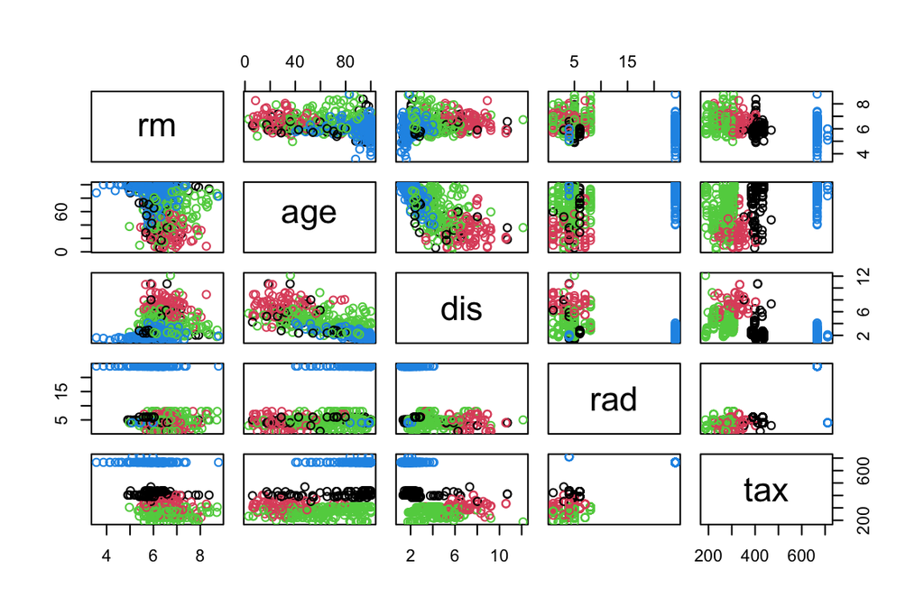

```r
set.seed(13)
km <- kmeans(Boston, centers = 4)

# plot the Boston dataset with clusters
km <- kmeans(Boston, centers = 4)

# plot the Boston dataset with clusters
pairs(Boston[6:10], col = km$cluster)
```

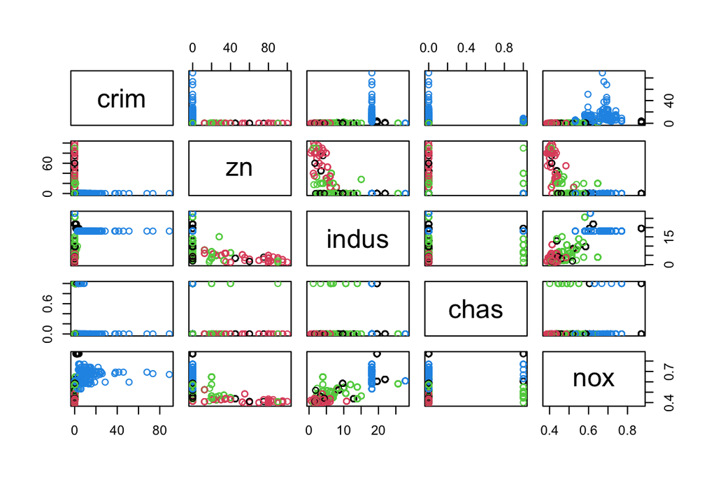

```r
pairs(Boston[1:5], col = km$cluster)
```

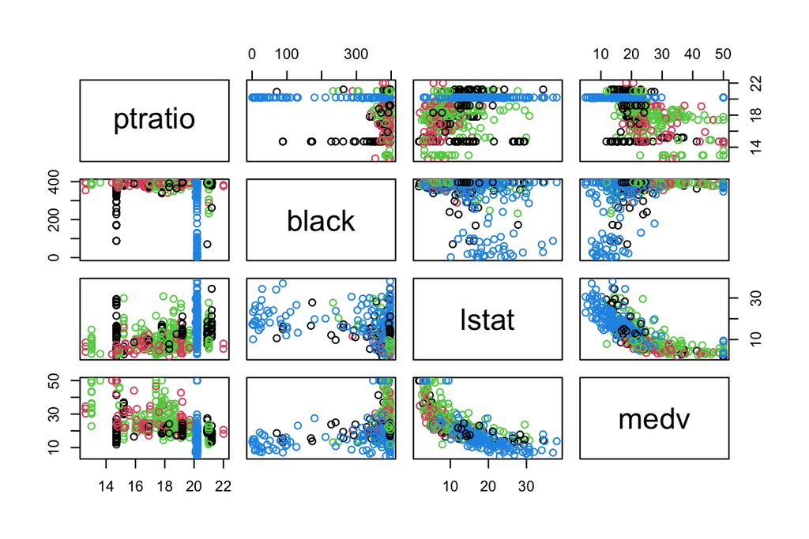

```r
pairs(Boston[11:14], col = km$cluster)
```

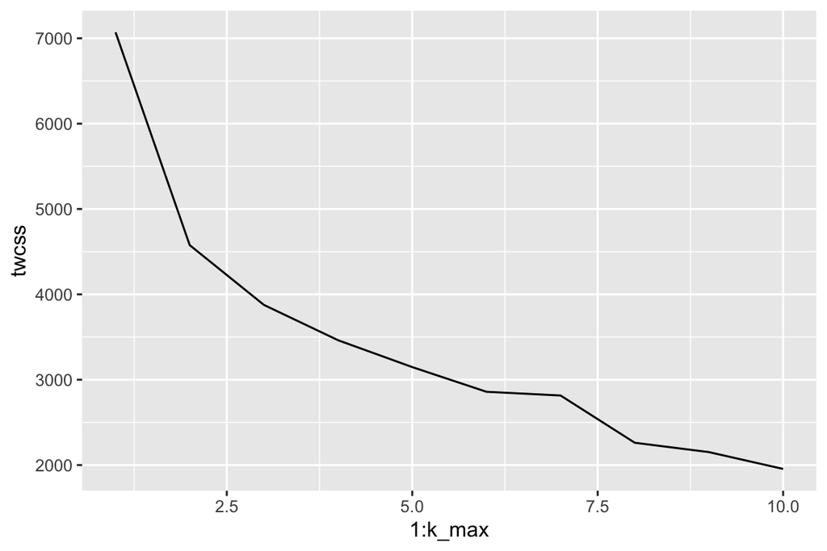

```r
set.seed(123)

# determine the number of clusters
k_max <- 10

# calculate the total within sum of squares
twcss <- sapply(1:k_max, function(k){kmeans(boston_scaled, k)$tot.withinss})

# visualize the results
qplot(x = 1:k_max, y = twcss, geom = 'line')
```

[figure not shown]

```r
# k-means clustering
km <- kmeans(Boston, centers = 2)

# plot the Boston dataset with clusters
pairs(Boston, col = km$cluster)
```

The optimal number of clusters can be found by looking at the sum of squares within clusters, and in the graph above I think the optimal number of clusters is close to 2. At an optimal cluster number of 2, the values vary significantly.

```r
xfun::Rscript_call(rmarkdown::render, list("chapter5.Rmd"))
```

```
## [1] "/Users/renyu/Desktop/IODS-project/chapter5.html"
```